# Homework 4

Hasmik Aleksanyan

04, May 2020

# Task 1: Poisson Regression: Data Cleaning and Description

Load the awards.csv file. Get rid of variables that are irrelevant for Poisson regression analysis using function select(). Pay attention to the last column of your data. Use the separate() function to solve the problem based on data description.

Check whether the data types are correct, if not, make appropriate corrections, assigning labels to each level according to the data description. Use the glimpse() function to see the structure of the final data.

Find your dependent variable for Poisson regression analysis. Plot the histogram of your target variable. Calculate the unconditional mean and variance of your target variable. What can you notice?

Find the categorical variables which affect your target variable using boxplots. Comment on it.

Use group_by() and summarise() functions to conclude about conditional variances and the means of your target variable grouped by categorical variables. Comment on it: do you have the problem of overdispersion?

## Solution 1

```r
dat <- read.csv("awards.csv")
dat <- dplyr::select(dat, c("awards", "math", "physics", "hpw", "gender", "imp", "school.prog"))
dat <- dat %>% separate('school.prog',  c('school', 'prog'))
dat$imp<-factor(dat$imp,levels = c(1,2,3,4), labels=c("Not important", "Slightly important", "Important", "Very important"))
dat$school<-factor(dat$school,levels = c('Public', 'Private'), labels=c('Public', 'Private'))
dat$prog<-factor(dat$prog,levels = c(0,1,2,3), labels=c('General', 'Pre-Academic', 'Academic', 'Vocational'))
glimpse(dat)
```

```
## Observations: 2,500
## Variables: 8
## $ awards  <int> 0, 0, 0, 0, 0, 0, 0, 0, 0, 0, 0, 0, 0, 0, 0, 0, 0, 0, 0, 0,...
## $ math    <dbl> 0, 0, 0, 0, 0, 0, 0, 0, 0, 0, 0, 0, 0, 0, 0, 0, 0, 0, 0, 0,...
## $ physics <dbl> 0, 0, 0, 0, 0, 0, 0, 0, 0, 0, 0, 0, 0, 0, 0, 0, 0, 0, 0, 0,...
## $ hpw     <dbl> 0, 0, 0, 0, 0, 0, 0, 0, 0, 0, 0, 0, 0, 0, 0, 0, 0, 0, 0, 0,...
## $ gender  <fct> female, female, female, female, female, female, female, fem...
## $ imp     <fct> Slightly important, Not important, Slightly important, Not ...
## $ school  <fct> Private, Private, Private, Private, Private, Private, Priva...
## $ prog    <fct> General, Pre-Academic, Pre-Academic, Academic, General, Aca...
```

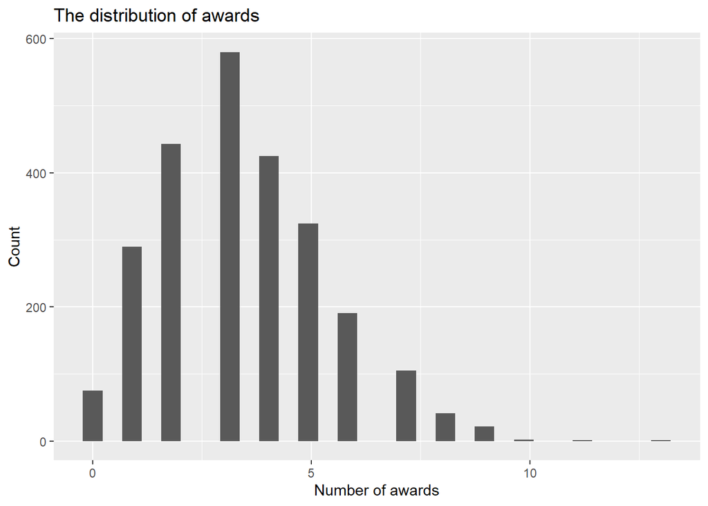

```r
ggplot(data = dat, aes( x = awards)) +
  geom_histogram(bins = 30) +
  labs (x = 'Number of awards', y = "Count") +
  ggtitle("The distribution of awards")
```

```r
dat %>%
  summarise(Mean = mean(awards), Var = var(awards), SD = sd(awards))
```

```
##     Mean      Var       SD
## 1 3.4748 3.566792 1.888595
```

We can see that on average students get 3 awards. And there is equidispersion.

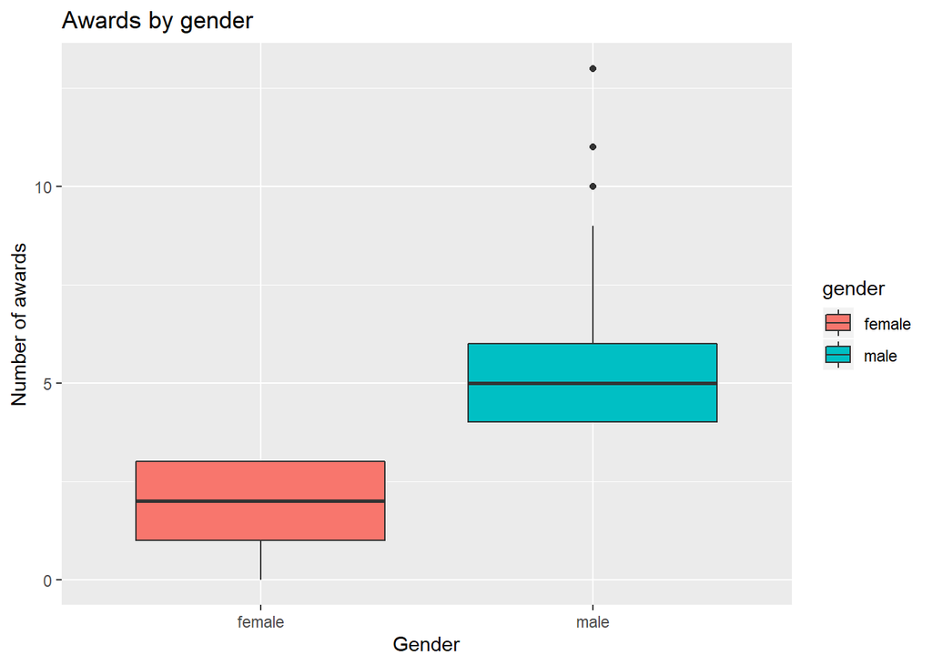

```r
ggplot(data = dat, aes(x = gender, y = awards, fill = gender)) +
  geom_boxplot()+
  labs(x = "Gender", y = "Number of awards", title = "Awards by gender")
```

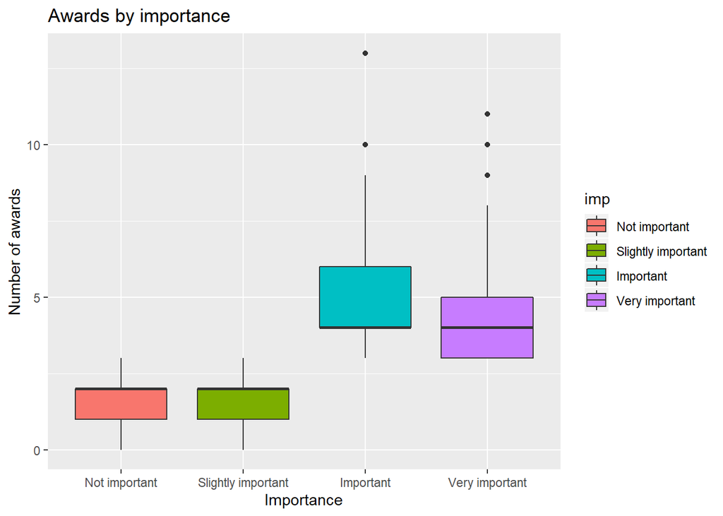

```r
ggplot(data = dat, aes(x = imp, y = awards, fill = imp)) +
  geom_boxplot()+
  labs(x = "Importance", y = "Number of awards", title = "Awards by importance")
```

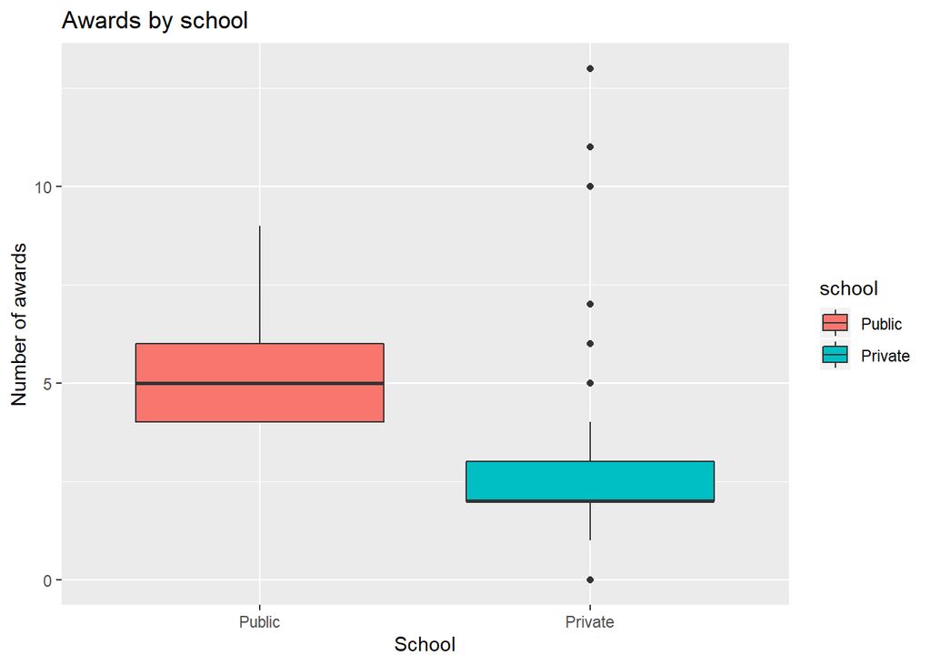

```r
ggplot(data = dat, aes(x = school, y = awards, fill = school)) +
  geom_boxplot()+
  labs(x = "School", y = "Number of awards", title = "Awards by school")
```

```r
dat %>% group_by(gender) %>%
  summarise(Mean = mean(awards) , Var = var(awards))
```

```
## # A tibble: 2 x 3
##   gender  Mean   Var
##   <fct>  <dbl> <dbl>
## 1 female  2.10 0.833
## 2 male    5.19 1.68
```

```r
dat %>% group_by(imp) %>%
  summarise(Mean = mean(awards) , Var = var(awards))
```

```
## # A tibble: 4 x 3
##   imp                 Mean   Var
##   <fct>              <dbl> <dbl>
## 1 Not important       1.77 0.753
## 2 Slightly important  1.74 0.691
## 3 Important           4.67 2.22
## 4 Very important      4.57 2.12
```

```r
dat %>% group_by(school) %>%
  summarise(Mean = mean(awards) , Var = var(awards))
```

```
## # A tibble: 2 x 3
##   school   Mean   Var
##   <fct>   <dbl> <dbl>
## 1 Public   5.41  1.59
## 2 Private  2.41  1.45
```

# Task 2: Poisson Regression: Modeling

Use the glm() function to perform an intercept-only Poisson regression model with your chosen target variable as the response. Use the output of your model to calculate the mean of your target variable.

Exclude from full model variables with insignificant coefficients. Show the result. Explain the meanings of coefficients of your model (at least one numeric and one categorical).

Pick your own new observation and predict the λ. Comment on it.

Calculate the probability of having more than 15 awards using your predicted λ from Problem 2 c.

Add to your data a new (created) variable with the problem of unconditional overdispersion.1 Show the problem by computing the average and variance of your variable. (Your variable needs to have a similar meaning to your target variable).

Run the model with the new variable as a response. Your model must contain only significant coefficients.

Use the function dispersiontest() to find out overdispersion. Formulate Null and Alternative hypotheses for trafo = Null (mathematically and explain it). Do you have an overdispersion?

Run the negative binomial and quasi-Poisson model. Show only coefficients. Find the best model based on deviance and AIC. Which is the best model? Why does not quasi-Poisson model have AIC?

## Solution 2

```r
model1 <- glm(awards ~ 1,  data = dat, family = poisson(link = log))
summary(model1)
```

```
##
## Call:
## glm(formula = awards ~ 1, family = poisson(link = log), data = dat)
##
## Deviance Residuals:
##     Min       1Q   Median       3Q      Max
## -2.6362  -0.8603  -0.2609   0.7672   3.9057
##
## Coefficients:
##             Estimate Std. Error z value Pr(>|z|)
## (Intercept)  1.24554    0.01073   116.1   <2e-16 ***
## ---
## Signif. codes:  0 '***' 0.001 '**' 0.01 '*' 0.05 '.' 0.1 ' ' 1
##
## (Dispersion parameter for poisson family taken to be 1)
##
##     Null deviance: 2752.4  on 2499  degrees of freedom
## Residual deviance: 2752.4  on 2499  degrees of freedom
## AIC: 10109
##
## Number of Fisher Scoring iterations: 4
```

```r
mean(dat$awards)
```

```
## [1] 3.4748
```

```r
exp(model1$coefficients)
```

```
## (Intercept)
##      3.4748
```

```r
model2 <- glm(awards ~ math + physics + hpw + gender,  data = dat, family = poisson(link = log))
summary(model2)
```

```
##
## Call:
## glm(formula = awards ~ math + physics + hpw + gender, family = poisson(link = log),
##     data = dat)
##
## Deviance Residuals:
##      Min        1Q    Median        3Q       Max
## -2.15398  -0.11619   0.01365   0.24624   1.16813
##
## Coefficients:
##             Estimate Std. Error z value Pr(>|z|)
## (Intercept) 0.314158   0.025211  12.461  < 2e-16 ***
## math        0.016594   0.002032   8.164 3.23e-16 ***
## physics     0.011940   0.001805   6.614 3.74e-11 ***
## hpw         0.013220   0.005486   2.410    0.016 *
## gendermale  0.273545   0.034115   8.018 1.07e-15 ***
## ---
## Signif. codes:  0 '***' 0.001 '**' 0.01 '*' 0.05 '.' 0.1 ' ' 1
##
## (Dispersion parameter for poisson family taken to be 1)
##
##     Null deviance: 2752.41  on 2499  degrees of freedom
## Residual deviance:  443.47  on 2495  degrees of freedom
## AIC: 7808.3
##
## Number of Fisher Scoring iterations: 4
```

```r
exp(model2$coefficients)
```

```
## (Intercept)        math     physics         hpw  gendermale
##    1.369105    1.016732    1.012012    1.013308    1.314616
```

1 unit of increase in math increases average number of awards awards by 1% and being male increases average number of awards by 31%.

```r
model3 <- glm(awards ~ math + school + gender,  data = dat, family = poisson(link = log))
newdat <- data.frame ( gender = "male", school = "Private", math = 7)
as.numeric(lambda <- predict(model3, newdata = newdat, type = "response"))
```

```
## [1] 2.580572
```

```r
x <- dpois (15, lambda = lambda)
format(x,  scientific=FALSE)
```

```
## [1] "0.00000008679827"
```

My model is predicting there will be roughly 3 awards if the student is male, type of school is private and his math score is 7.

```r
set.seed(27)
dat$award <- rnbinom(n = 2500, size = 13, mu = 4)
mean(dat$award)
```

```
## [1] 3.9476
```

```r
var(dat$award)
```

```
## [1] 5.323784
```

```r
model4 <- glm(award ~  school + gender,  data = dat, family = poisson(link = log))
summary(model4)
```

```
##
## Call:
## glm(formula = award ~ school + gender, family = poisson(link = log),
##     data = dat)
##
## Deviance Residuals:
##     Min       1Q   Median       3Q      Max
## -2.8576  -1.0482  -0.0411   0.5499   3.9683
##
## Coefficients:
##               Estimate Std. Error z value Pr(>|z|)
## (Intercept)    1.52877    0.04195  36.439  < 2e-16 ***
## schoolPrivate -0.12198    0.03980  -3.065  0.00218 **
## gendermale    -0.17576    0.03832  -4.587 4.51e-06 ***
## ---
## Signif. codes:  0 '***' 0.001 '**' 0.01 '*' 0.05 '.' 0.1 ' ' 1
##
## (Dispersion parameter for poisson family taken to be 1)
##
##     Null deviance: 3496.3  on 2499  degrees of freedom
## Residual deviance: 3472.2  on 2497  degrees of freedom
## AIC: 11086
##
## Number of Fisher Scoring iterations: 5
```

```r
dispersiontest(model4, trafo = NULL)
```

```
##
##  Overdispersion test
##
## data:  model4
## z = 8.6795, p-value < 2.2e-16
## alternative hypothesis: true dispersion is greater than 1
## sample estimates:
## dispersion
##   1.335924
```

Null and Alternative hypotheses

$H_0: VAR[y] = \mu$ equidispersion $H_1:VAR[y] = \mu + \alpha * trafo(\mu)$  
$trafo(\mu) = \mu => VAR[y] = (1 + \alpha) * \mu = dispersion * \mu$

dispersion = 1.335924 > 1 => there is overdispersion

```r
model.qp <- glm(award ~  school + gender,  data = dat, family = quasipoisson(link = log))
summary(model.qp)
```

```
##
## Call:
## glm(formula = award ~ school + gender, family = quasipoisson(link = log),
##     data = dat)
##
## Deviance Residuals:
##     Min       1Q   Median       3Q      Max
## -2.8576  -1.0482  -0.0411   0.5499   3.9683
##
## Coefficients:
##               Estimate Std. Error t value Pr(>|t|)
## (Intercept)    1.52877    0.04852  31.508  < 2e-16 ***
## schoolPrivate -0.12198    0.04602  -2.650  0.00809 **
## gendermale    -0.17576    0.04432  -3.966 7.52e-05 ***
## ---
## Signif. codes:  0 '***' 0.001 '**' 0.01 '*' 0.05 '.' 0.1 ' ' 1
##
## (Dispersion parameter for quasipoisson family taken to be 1.337529)
##
##     Null deviance: 3496.3  on 2499  degrees of freedom
## Residual deviance: 3472.2  on 2497  degrees of freedom
## AIC: NA
##
## Number of Fisher Scoring iterations: 5
```

```r
model.nb <- glm.nb(award ~  school + gender,  data = dat)
summary(model.nb)
```

```
##
## Call:
## glm.nb(formula = award ~ school + gender, data = dat, init.theta = 11.78911333,
##     link = log)
##
## Deviance Residuals:
##     Min       1Q   Median       3Q      Max
## -2.6480  -0.9307  -0.0355   0.4718   3.2053
##
## Coefficients:
##               Estimate Std. Error z value Pr(>|z|)
## (Intercept)    1.52877    0.04788  31.930  < 2e-16 ***
## schoolPrivate -0.12198    0.04533  -2.691  0.00713 **
## gendermale    -0.17576    0.04365  -4.027 5.65e-05 ***
## ---
## Signif. codes:  0 '***' 0.001 '**' 0.01 '*' 0.05 '.' 0.1 ' ' 1
##
## (Dispersion parameter for Negative Binomial(11.7891) family taken to be 1)
##
##     Null deviance: 2672.3  on 2499  degrees of freedom
## Residual deviance: 2654.1  on 2497  degrees of freedom
## AIC: 10975
##
## Number of Fisher Scoring iterations: 1
##
##
##               Theta:  11.79
##           Std. Err.:  1.36
##
##  2 x log-likelihood:  -10966.69
```

```r
data.frame(coef(model4), coef(model.qp), coef(model.nb))
```

```
##               coef.model4. coef.model.qp. coef.model.nb.
## (Intercept)      1.5287745      1.5287745      1.5287745
## schoolPrivate   -0.1219785     -0.1219785     -0.1219785
## gendermale      -0.1757591     -0.1757591     -0.1757591
```

```r
data.frame(deviance(model4),deviance(model.nb),deviance(model.qp))
```

```
##   deviance.model4. deviance.model.nb. deviance.model.qp.
## 1          3472.19           2654.108            3472.19
```

```r
data.frame(model4$aic,model.nb$aic)
```

```
##   model4.aic model.nb.aic
## 1   11086.17     10974.69
```

Negative binomial model is the best, cause it has the smallest deviance and AIC. Quasipoisson regression uses Quasi-Likelihood estimation, thus it doesn’t have AIC.

# Task 3: Regularization

Load movies_data.xls and get rid of one useless variable. Split data into train and test using the following proportion 60:40, respectively.

Fit a linear model using least squares on training set, and report the test error obtained.

Fit a ridge regression on training set, with λ chosen by cross-validation. Report the test error obtained.

Fit a LASSO model on the training set, with λ chosen by cross-validation. Report the test error obtained, along with the number of non-zero coefficient estimates.

Find the best elastic net with α and λ chosen by cross-validation.

Is there much difference among the test errors resulting from these four approaches. Which one is the best?

## Solution 3

```r
dt <- read.xlsx("movies_data.xlsx")
dt <- dplyr::select(dt, -c('X1'))

set.seed(27)
sample <- sample(nrow(dt), nrow(dt) * 0.6, replace = F)
train <- dt[sample, 1:15]
test <- dt[-sample, 1:15]

x <- model.matrix(budget_adjusted ~ .,train)[,-1]
y <- train$budget_adjusted

xt <- model.matrix( budget_adjusted ~ .,test)[,-1]
yt <- test$budget_adjusted
```

```r
lm.mod <- lm(budget_adjusted ~ ., data = train)
lm.mod.pred=predict(lm.mod, test)
lm.mod.mse=round(mean((yt-lm.mod.pred)^2))
lm.mse <- format(lm.mod.mse,  scientific=FALSE)
```

```r
set.seed(2708)
grid <- exp(seq(-2,11, length = 100))
ridge.cv <- cv.glmnet(y = y, x = x, lambda = grid, alpha = 0, nfolds = 10)
ridge.mod <- glmnet(y = y, x = x, alpha=0, lambda=ridge.cv$lambda.min, standardize = T)

ridge.pred = predict(ridge.mod, s = ridge.cv$lambda.min, newx = xt)
ridge.mse = mean((ridge.pred - yt)^2)

ridge.mse <- format(ridge.mse,  scientific=FALSE)
```

```r
set.seed(2708)
grid <- exp(seq(-2,11, length = 100))
lasso.cv <- cv.glmnet(y = y, x = x, lambda = grid, alpha = 1, nfolds = 10)

lasso.mod <- glmnet(y = y, x = x, lambda=lasso.cv$lambda.min, alpha=1, standardize = T)

lasso.pred = predict(lasso.mod, s = lasso.cv$lambda.min, newx = xt)
lasso.mse = mean((lasso.pred - yt)^2)

lasso.mse <- format(lasso.mse,  scientific=FALSE)
```

```r
models <- list()
set.seed(2708)
for (i in 0:10) {
  name <- paste0("alpha", i/10)
  models[[name]] <- cv.glmnet(x, y, type.measure="mse", alpha=i/10)
}

results <- data.frame()

for (i in 0:10) {
  name <- paste0("alpha", i/10)
  predicted <- predict(models[[name]], s = models[[name]]$lambda.min, newx = xt)
  mse <-mean((yt - predicted)^2)
  temp <- data.frame(alpha=i/10, mse = mse, name = name)
  results <- rbind(results, temp)
}

elnet.mse <- format(min(results$mse),  scientific=FALSE)
```

```r
data.frame(lm.mse, ridge.mse, lasso.mse, elnet.mse)
```

```
##           lm.mse      ridge.mse      lasso.mse      elnet.mse
## 1 52214588896517 52227603798343 52351888771503 52269035260369
```

There is not much difference among the test errors resulting from these four approaches. The linear model has the smallest mse so it is the best.

# Questions

a.What is the equidispersion in Poisson regression? Why do we need to avoid overdispersion?

b.Why Poisson regression is called log-linear?

c.What is regularization? Why do we need it?

d.Describe the main idea of ridge regression.

e.What is the difference between ridge and LASSO regression?

f.How much time did it take to accomplish the HW?

## Answers

1. If var(y|x) = mean(y|x) => there is equidispersion. If there is overdispersion poisson regression will estimate wrong standard errors.
2. Because we use log on the average value of the dependent variable.
3. Regularization solves multicollinearity problem. It performs linear regression model, while shrinking the coefficients $\hat{\beta}$ toward 0.
4. The main idea is to find new line with small amount of bias in order to have less variance.
5. Ridge regression includes all predictors in the final model while lasso doesn’t, it can estimate coefficients 0 value. They differ with the penalty term.
6. Maybe 3 or 4 days.